# CHAPTER A-16

# 圧力容器における膜応力

## アルフレッド・F・シュミット (ALFRED F. SCHMITT)

### A16.1 はじめに

構造設計者は、圧力を受ける流体を封入するための容器の開発を求められることがよくある。時として、そのような容器の設計は重量や形状の観点から重要ではなく、十分に強力で密閉された容器であれば、ほぼどのようなものでも用を足すことがある。しかし、多くの場合、そのようなユニットの強度、重量、および形状は厳密に規定され、厳格に管理される。したがって、近代的な航空機の与圧キャビンは、ほぼ海面気圧の空気を保持する密閉された圧力容器であり、その機能的要件には以下のものが含まれる：

i - 尾翼面からの重い荷重および内部の固定荷重の伝達、

ii - ドアや窓のための非構造的な切り欠きの必要性、

iii - 空力および空間利用の両方の観点から効率的な形状、

iv - 最小限の重量。

構造的に、最も効率的な形式の圧力容器は、容器の湾曲した壁における引張応力のみによって横圧力が支持されるものである。このような形状の例としては、加圧されたゴム風船やキャンバス製の消火ホース、および水滴の自由表面（表面張力が支持を提供する）によって形成される形状が挙げられる。これらの容器の壁は曲げ剛性がゼロであり、したがって膜（メンブレン）の特性を持つ。各点において完全に接線方向に発生する応力は、膜応力と呼ばれる。

技術的に重要なシェルにおいては、当然ながら壁にある程度の曲げ剛性があり、したがって曲げ応力によってある程度の横荷重を支持することができる。実際、シェルに課される境界条件は、端部や継ぎ目の近くで局所的な曲げを必要とするようなものである場合がある。効率的な圧力容器の設計とは、真の膜応力状態からのこれらの逸脱を最小限に抑える、すなわち、誘発される局所的な曲げ応力の程度を最小限に抑える構成のものである。

### A16.2 膜の平衡方程式：回転対称な圧力荷重を受ける回転殻

図 A16-1 の回転殻から切り取られた微小要素の平衡を考える。（この図は、視覚化を助けるために、よく知られている折り紙のクリスマスのベルに似せて描かれている。）この要素は、一対の隣接する子午線曲線と一対の隣接する平行円の交差によって切り取られる。

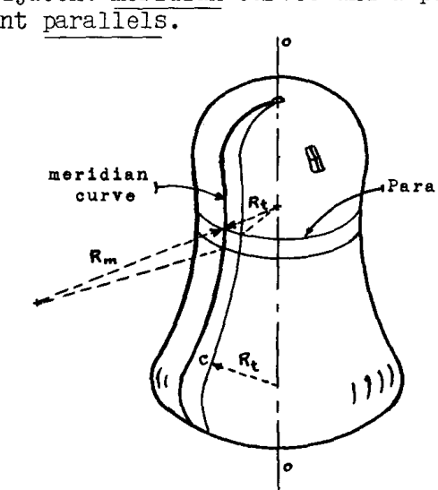

Fig. A16.1

図に示されている半径 $R_m$ および $R_t$ は、要素の角において表面に局所的な法線を立てることによって求められる。 $R_m$ は子午線曲線の曲率半径である：これは正（内側を向く）、負（図 A16-1 のように外側を向く）、または無限大（変曲点または直線の子午線セグメントにおいて）のいずれかになり得る。 $R_t$ は子午線曲線に垂直な断面の曲率半径である。単純な形式の圧力容器の場合、 $R_t$ は常に正である。すべての半径 $R_t$ は内側を向き、軸 O-O と交差するが、一般に O-O に垂直ではない（図 A16-1 の点 C から立てられた半径 $R_t$ を参照）。

図 A16-2 は表面要素の詳細である。子午線方向および接線方向の単位長さあたりの力*は、それぞれ $N_m$ および $N_t$ で表される。剪断応力は問題の対称性により存在しない。子午線方向および接線方向の力のペアの間の挟角は、それぞれ $ds_m/R_m$ および $ds_t/R_t$ である。

微小要素に垂直な力を足し合わせると、次のようになる。

$$N_m \, ds_t \, \frac{ds_m}{R_m} + N_t \, ds_m \, \frac{ds_t}{R_t} = p \, ds_m \, ds_t$$

または、

$$\frac{N_m}{R_m} + \frac{N_t}{R_t} = p \qquad \text{--- (1)}$$

ここで $p$ は内圧であり、外向きを正とする。シェルの肉厚は式 (1) に入らないことに注意されたい。圧力 $p$ は子午線方向には変化し得るが、仮定（回転対称性を想定）により接線方向には一定である。

式 (1) は2つの未知数を含む1つの方程式である。もう1つの関係式は、平行円の上方または下方のシェルの一部の平衡条件によって得ることができる。したがって、図 A16-3 において、シェルの下部に下向きに作用する圧力は、子午線応力 $N_m$ の上向きの垂直成分によって釣り合っている。

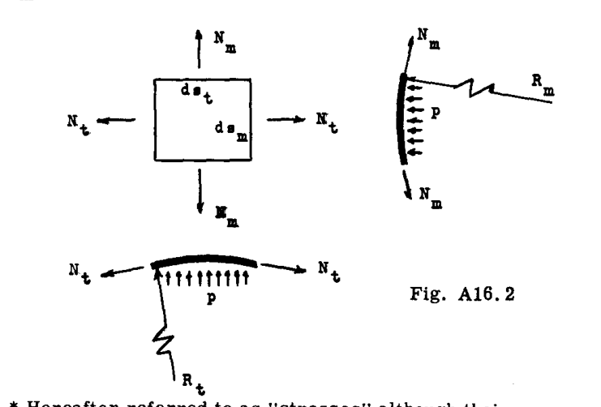

Fig. A16.2

- 以下、単位が psi ではなくポンド/インチであっても「応力」と呼ぶ。

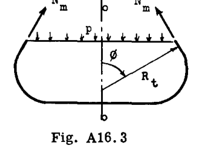

Fig. A16.3

垂直方向の力を足し合わせると、

$$p \pi (R_t \sin \phi)^2 = 2 \pi (R_t \sin \phi) N_m \sin \phi$$

これを解くと、

$$N_m = p \frac{R_t}{2} \qquad \text{--- (2)}$$

式 (1) と (2) は、回転対称シェル問題における膜応力状態を完全に決定する。したがって、この問題は静定であることがわかる。

式 (2) は静水圧荷重の場合には使用すべきではないことに注意されたい。基本概念はシェルの平衡であり、したがってこのクラスの問題ではシェルの支持方法を考慮しなければならない。したがって、図 A16-4a のタンクでは、荷重が支持リング O-O で反力を受けるため、上部の円筒部には子午線応力を必要としない。（これらの解析において、常に支持のためのいくつかの応力を必要とする構造重量は無視される。）下半球部分では、図 A16-4b に示すように子午線応力が必要とされる。したがって、このクラスの問題では、構造の個別の特性を考慮することによって、必要な第2の平衡方程式（式 2 に対応）を導き出すのが最善である。

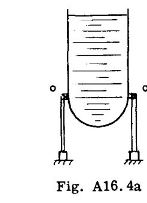

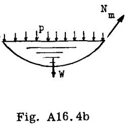

### A16.3 簡易圧力容器への応用

#### 例題 1

内圧が $p$ である、半球形の端部を持つ円形断面（半径 $R_o$ ）の円筒形圧力容器の膜応力を求めよ。また、最大の複合法線応力を求めよ。

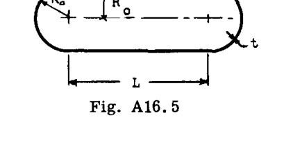

Fig. A16.5

**解答:**

半球形の端部では、対称性により $N_m = N_t$ であり、当然 $R_m = R_t = R_o$ である。したがって、式 (1) はこの部分の応力を決定するのに十分である。次のようになる。

$$2 \frac{N_m}{R_o} = 2 \frac{N_t}{R_o} = p$$

$$N_m = N_t = \frac{p R_o}{2}$$

$$\text{応力} = \frac{N_m}{t} = \frac{N_t}{t} = \frac{p R_o}{2t}$$

円筒部において、半径は $R_m = \infty$ である（図 A16-5 の曲線は子午線曲線であり、これは円筒部では直線である）。

$$R_t = R_o$$

式 (1) は次のようになる。

$$\frac{N_m}{\infty} + \frac{N_t}{R_o} = p$$

$$N_t = p R_o$$

$$\text{応力} = \frac{N_t}{t} = \frac{p R_o}{t}$$

円筒部の子午線応力は式 (2) から求められる。

$$N_m = \frac{p R_o}{2}$$

$$\text{応力} = \frac{p R_o}{2t}$$

子午線方向および接線方向のいたるところで剪断応力は存在しないため、これらは主応力の方向である。したがって、最大の複合法線応力は、計算されたばかりの最大の子午線応力または接線応力と恒等的に等しい。それは次のようになる。

$$s_{\max} = \frac{p R_o}{t}$$

#### 例題 2

与圧キャビンの設計における重要な問題は、端部隔壁の形状に関するものである。半球形の隔壁（例題 1 で使用されたようなもの）は応力の観点からは非常に望ましいが、スペースの利用という点では不経済である。もう一方の極端として、平らな隔壁は、はるかに有用な容積を提供する一方で、膜応力によって圧力荷重に抵抗することができず、したがって構造的に非効率的である。妥協的な構成は図 A16-6 に示すものであり、ここでは隔壁は曲率の低い球面（「皿形鏡板」）であり、膜応力によって圧力荷重を支持している。継ぎ目に配置された補強リングが、これらの応力の径方向成分に抵抗する。問題：補強リングに作用する圧縮荷重を求めよ。

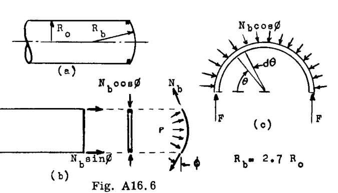

Fig. A16.6

**解答:** 図 A16-6b の展開図に示すように、隔壁応力の径方向成分は補強リングによって抵抗され、シリンダー壁は集中横力に対して抵抗を提供しないものと仮定される。

この場合、 $\phi = \arcsin \frac{1}{2.7} = 21.7^\circ$ である。

式 (1) から、 $N_m = N_t = N_b$ とすると、

$$N_b = \frac{2.7 R_o p}{2}$$

したがって、

$$N_b \cos \phi = \frac{2.7 R_o p}{2} (.929)$$

$$= 1.25 R_o p$$

最後に、圧縮リング荷重 $F$ は次のようになる（図 A16-6c を参照）。

$$2F = \int_0^\pi 1.25 R_o p \sin \theta R_o d\theta = 2.5 R_o^2 p$$

この結果から補強リングの応力を計算する際には、リングの断面積が計算されるときに、隣接するシェル壁からのいくつかの有効な外板を含める必要がある。

#### 例題 3

円形圧力シリンダーを閉じるために使用される別の形式の隔壁は、図 A16-7 に示すように断面が楕円形である。このような隔壁形状は、継ぎ目において接線方向の子午線力を提供し（前の例のような補強リングを必要としない）、しかも空間利用に関して合理的に効率的である。問題：このような隔壁における膜応力を決定せよ。

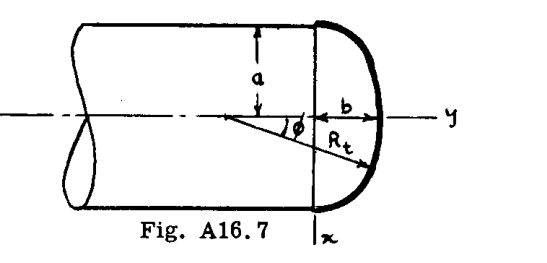

Fig. A16.7

**解答:** デカルト座標において、隔壁子午線の式は次の通りである。

$$\frac{x^2}{a^2} + \frac{y^2}{b^2} = 1$$

微積分から、この子午線曲線の曲率半径は次のようになる。

$$R_m = \frac{\left[1 + \left(\frac{dy}{dx}\right)^2\right]^{3/2}}{\frac{d^2y}{dx^2}} = \frac{(a^4y^2 + b^4x^2)^{3/2}}{a^4b^4}$$

半径 $R_t$ は、それが子午線曲線への接線に対して法線であることに注目することによって最も容易に見出される（図を参照）。接線の傾き（角度 $\phi$ ）を求めた後、 $R_t = x / \sin \phi$ を計算する。結果は次の通りである。

$$\sin \phi = \frac{b^2x}{(a^4y^2 + b^4x^2)^{1/2}}$$

$$R_t = \frac{(a^4y^2 + b^4x^2)^{1/2}}{b^2}$$

子午線応力は式 (2) から求められる。したがって、

$$N_m = \frac{p R_t}{2} = \frac{p}{2} \frac{(a^4y^2 + b^4x^2)^{1/2}}{b^2}$$

$R_m$ 、 $R_t$ 、および $N_m$ の式を式 (1) に代入すると、次のようになる。

$$N_t = p \frac{(a^4y^2 + b^4x^2)^{1/2}}{b^2} \left[1 - \frac{a^4b^2}{2 (a^4y^2 + b^4x^2)}\right]$$

特に興味深いのは、継ぎ目における応力である。ここでは $y = 0$ 、 $x = a$ である。次のようになる。

$$N_m = \frac{pa}{2}$$

$$N_t = pa \left(1 - \frac{a^2}{2b^2}\right)$$

この最後の結果は、 $a > b \sqrt{2}$ の場合に圧縮接線応力が可能であることを示しているため重要である。以下で見るように、このような状況は、シリンダーと隔壁の間の径方向膨張に大きな差が生じ（ $N_t$ が負の場合、隔壁は実際に径方向に収縮する）、シェル壁に高い二次曲げ応力を発生させるため望ましくない。

#### 例題 4

図 A16-8 の幾何学的パラメータ、内圧、許容応力の関数として、二重円筒胴体断面の単位長さあたりの重量を求めよ。構造効率のために、外板と床における膜応力を等しく維持することが望まれる。

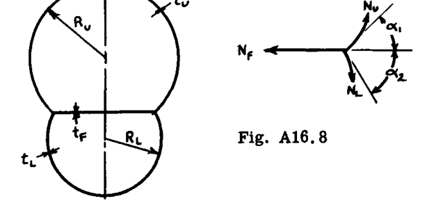

Fig. A16.8

**解答:**

式 (1) から、上部および下部の円筒形ロブにおける「フープ」荷重は次の通りである。

$$N_U = p R_U$$

$$N_L = p R_L$$

床の接合部において水平方向の力を足し合わせると、

$$N_f = p (R_U \cos \alpha_1 + R_L \cos \alpha_2)$$

すべての応力が等しく、 $s$ で与えられると仮定する。

$$s_U = s = \frac{p R_U}{t_U}$$

$$s_L = s = \frac{p R_L}{t_L}$$

$$s_f = s = \frac{p}{t_f} (R_U \cos \alpha_1 + R_L \cos \alpha_2)$$

材料の重量密度を $w$ とすると、キャビンに沿った（軸方向の）単位長さあたりの重量は（ $w$ に壁と床の展開長さを乗じたもの）である。

$$W = w \left\{2 t_U R_U (\pi - \alpha_1) + 2 t_L R_L (\pi - \alpha_2) + 2 t_f R_U \sin \alpha_1\right\}$$

上記からさまざまな厚さを解き、代入すると、次のようになる（見かけ上対称な結果を得るために、 $R_U \sin \alpha_1 = R_L \sin \alpha_2$ という事実が使用された）。

$$W = \frac{2wp}{s} \left\{R_U^2 \left(\pi - \alpha_1 + \frac{1}{2} \sin 2\alpha_1\right) + R_L^2 \left(\pi - \alpha_2 + \frac{1}{2} \sin 2\alpha_2\right)\right\}$$

この胴体の断面積は次のようになることを示せるため、

$$A = R_U^2 \left(\pi - \alpha_1 + \frac{1}{2} \sin 2\alpha_1\right) + R_L^2 \left(\pi - \alpha_2 + \frac{1}{2} \sin 2\alpha_2\right)$$

この計算の重要な結果は、シェル重量とシェル体積の比が次のようになることである。

$$\frac{W}{A} = \frac{2wp}{s}$$

したがって、これは使用される $R_U$ 、 $R_L$ 、 $\alpha_1$ 、および $\alpha_2$ の組み合わせに依存しない。したがって、設計者は他の要件を満たすようにこれらの形状パラメータを自由に選択することができる。

#### 例題 5

高さ $h$ 、半頂角 $\alpha$ の円錐形容器における膜応力を求めよ。円錐は、比重量 $w$ の液体で満たされ、円錐の上に液体ヘッド $H$ を有する大きな容器の底部を形成している。ユニット全体は上方から支持されている。

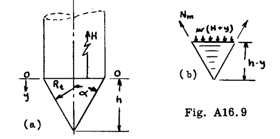

Fig. A16.9

**解答:**

円錐の子午線曲線は曲率半径 $R_m = \infty$ を持ち、円錐の頂部から距離 $y$ 下方の任意の点において、半径 $R_t$ は次の通りである。

$$R_t = \frac{(h - y) \tan \alpha}{\cos \alpha}$$

次に、任意のレベル $y$ において式 (1) から、

$$N_t = p R_t = \frac{w (H + y) (h - y) \tan \alpha}{\cos \alpha}$$

円錐の子午線応力 $N_m$ を求めるために、高さ $h - y$ のセグメントの平衡を考える（図 A16-9b）。垂直方向の力を足し合わせると、

$$N_m \cdot 2 \pi (h - y) \tan \alpha \cos \alpha = \pi (h - y)^2 \tan^2 \alpha \cdot w (H + y) + w \frac{\pi}{3} (h - y)^3 \tan^2 \alpha$$

これを解くと、

$$N_m = \frac{w \tan \alpha}{2 \cos \alpha} (h - y) \left[H + y + \frac{1}{3} (h - y)\right]$$

### A16.4 薄肉シェルにおける変位、境界条件、および局所曲げ

ここで、前述の例示的なケースのいくつかを調べて、計算された膜応力がシェル応力の十分に正確な尺度を提供したかどうかを判断することが適切である。答えを予想して述べると、膜解析はシェル状の圧力容器において一次応力状態を与えるが、境界効果によって引き起こされる誘発曲げの注意深い（そしてしばしば長い）解析は、局所的な二次応力のピークを明らかにする。適切に設計された*容器の静的強度解析においては、これらの二次応力ピークを無視するのが一般的であり、材料の局所的な降伏がそれらを均一化すると主張される。しかし、そのような応力ピークは、疲労破壊が起こりやすいと考えられる繰り返し荷重の場合には非常に重要であることが判明する可能性がある。

膜解析の大きな弱点を指摘するには、図 A16-5 の圧力容器を構成する2つの異なる要素、すなわち円筒と半球形隔壁における径方向変位を計算するだけで十分である。フックの法則により、円筒の接線歪みは次の通りである（アルミニウムの場合、ポアソン比 $\mu = .3$ ）。

$$\epsilon_{\text{CYL}} = \frac{1}{E} (s_t - \mu s_m)$$

$$= \frac{p R_o}{Et} \left(1 - \frac{\mu}{2}\right) = .85 \frac{p R_o}{Et}$$

積分により、円筒上の任意の点の径方向変位は次のようになることがわかる（図 A16-10 を参照）。

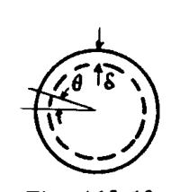

Fig. A16.10

$$\delta_{\text{CYL}} = \int_0^{\pi/2} \epsilon_{\text{CYL}} \cos \theta R_o d\theta = .85 \frac{p R_o^2}{Et}$$

継ぎ目に隣接して、半球形隔壁における接線歪みは次の通りである。

$$\epsilon_{\text{BLKHD}} = \frac{p R_o}{2Et} (1 - \mu) = .35 \frac{p R_o}{Et}$$

したがって、積分により、

$$\delta_{\text{BLKHD}} = .35 \frac{p R_o^2}{Et}$$

したがって、円筒は隔壁よりも大きく膨張する傾向があり、この状況はこれらの要素間の継ぎ目によって妨げられる。したがって、継ぎ目は図 A16-11 に示すような横方向の剪断作用を受ける。これらの剪断力は、図に示すように、シェル壁に曲げモーメントを発生させる。

- さまざまなコードや規格が、二次応力を正しく制限する一般的な容器の比率を与えている。例えば、参考文献 (1) を参照。

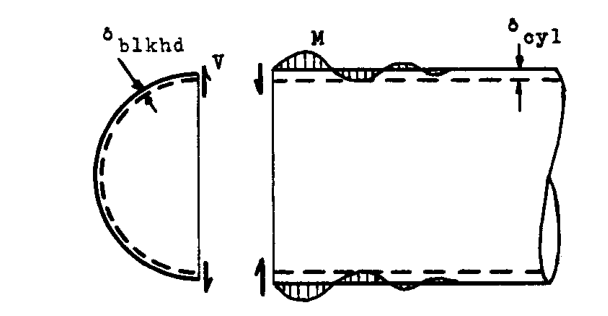

Fig. A16.11

ここではシェルの曲げについて詳細に取り上げることはしないが、これらの曲げ応力の性質と大きさを適切に把握できるように、いくつかの指標を示す必要がある。これらの壁モーメントについて最も顕著なことは、それらが急速に減衰し、継ぎ目から約 $4 \sqrt{R_o t}$ の距離で無視できるほど小さく（最大値の 1/10 まで）なることである。したがって、例えば半径 40 インチ、肉厚 .065 インチの円形円筒シェルの場合、これらのモーメントは継ぎ目から 6.5 インチで減衰する。

次に重要な考慮事項は、これらの二次曲げ応力の大きさを評価することである。図 A16-5 の圧力容器の場合、子午線応力は最大モーメントの点で約 30% 増加するが、接線応力は約 3% しか増加しない。幸いなことに、このクラスの容器では、接線応力が設計基準となる応力であり（子午線応力の2倍の大きさ）、したがって二次応力はこのケースではほとんど重要ではない（参考文献 2 の第 11 章、389〜422 ページを参照）。他の構成では、常にこのように幸運であるとは限らず、詳細な解析が必要になる場合がある（参考文献 3、4、5、および 6 を参照）。

上記の容器の継ぎ目における状況は、別々に荷重をかけた場合に異なる膨張を経験する要素が接合される多くの継ぎ目や境界の典型である。そのような継ぎ目や境界には、以下のようなものがある：

i - 子午線曲率が急激に変化する場所。図 A16-5 の継ぎ目では、 $R_m = R_o$ から $R_m = \infty$ に変化する。

ii - 子午線曲線の方向が急激に変化する場所。前述の例題 5 では、継ぎ目の近くでかなりのシェル壁曲げが誘発される。実際、前述の例題 2 のように、継ぎ目に補強リングを追加する必要がある。*

iii - 異なる剛性と異なる荷重を持つ構造部材が接合される場所。例題 2 では、シリンダーが最も膨張する傾向があり、隔壁はかなり少なく、圧縮荷重を受ける補強リングは収縮する傾向がある。このタイプの他の継ぎ目および/または境界は、シェル壁の厚さが急激に変化する場所（ダブラーの追加）や、シェルが基礎に固定されている場所である。

優れた設計は、高度に不適合な歪みを持つ要素の組み合わせを避けることにより、二次曲げ応力の大きさを最小限に抑える傾向がある。したがって、例題 3 の解析は、 $a = 2b$ である楕円形隔壁で円形圧力シリンダーを閉じると、隔壁に圧縮接線応力が発生することを示している。このような場合、隔壁は径方向に収縮する傾向があるが、メインシリンダーは常に膨張する傾向がある。したがって、継ぎ目における剪断力と誘発モーメントが悪化し、（たまたま）接線方向の最大応力が膜応力を 13% 上回る（半球形隔壁ではわずか 3% 上回るのに対して）（参考文献 2、410 ページ）。しかし、このタイプの隔壁では、ボイラーコードで $a/b$ の比率を 2.6 まで許可することがある。

### A16.4 与圧キャビン応力解析における特殊問題

単純な圧力容器の要件に加えて、機能的な要件があるため、航空機の与圧キャビンシェルには、その構成に特有の多くの応力解析問題がある。ここでは、これらのうちより一般的なもののいくつかについて検討する。

#### 外板とストリンガーの間の応力分布

胴体を介して重い尾翼荷重を伝達する際にシェル壁を安定させるために、縦方向のストリンガーが追加される。これらの同じストリンガーは、子午線方向の圧力荷重を支持するのにも役立つ。外板とストリンガーは、当然ながら縦方向に等しい歪みを持たなければならないが、外板は二次元応力状態にあるため、等しい縦方向応力を持つことはできない。したがって、以下の解析を行う。

外板とストリンガーにおける子午線方向（縦方向）の応力をそれぞれ $s_m$ および $s_L$ とする。 $s_t$ は外板における接線（フープ）応力である。式 (1) から、再び次のようになる。

$$s_t = \frac{p R_o}{t}$$

$N$ をストリンガーの総数とし、それぞれの断面積を $A_L$ とすると、縦方向の平衡には次の条件が必要である。

$$p \pi R_o^2 = 2 \pi R_o t \, s_m + N A_L s_L$$

外板とストリンガーにおける縦方向の歪みが等しいという条件から、次のようになる。

$$E \epsilon = s_L = s_m - \mu s_t$$

ここで $\mu$ はポアソン比（アルミニウムの場合は = .3）である。これら3つの方程式を解くと、次のようになる。

$$s_t = \frac{p R_o}{t}$$

$$s_m = \frac{p R_o}{2t} \frac{(1 + 2 \mu \alpha)}{(1 + \alpha)} = \frac{p R_o}{2t} \frac{(1 + .6 \alpha)}{(1 + \alpha)}$$

$$s_L = \frac{p R_o}{2t} \frac{(1 - 2 \mu)}{(1 + \alpha)} = \frac{p R_o}{2t} \frac{.4}{(1 + \alpha)}$$

ここで $\alpha = N A_L / 2 \pi R_o t$ は、外板面積に対する全ストリンガー面積の比率である。少し検討すると、 $t(1 + \alpha)$ は一種の「有効シェル壁厚」であることがわかる：これは、すべての断面積（外板プラスストリンガー）を周囲に均一に分散させた結果である。この基準に基づくと、結果は少し期待外れである。ストリンガーは、全縦方向荷重（ $p \pi R_o^2$ ）が全断面積（ $2 \pi R_o t (1 + \alpha)$ ）に均一に分散された場合に期待される応力の 40% しか負担していない。

子午線方向の外板応力は、ストリンガーがない場合の値から $(1 + .6 \alpha)/(1 + \alpha)$ の係数で減少する。通常の比率の構造の場合、この減少は 20〜30% に達することがあるが、明らかに 40% を超えることはできない。尾翼荷重による曲げ応力はこれらの圧力膜応力に重畳されるため、この減少は確かに有益である*。

#### リングとシェルの相互作用

キャビン内部や翼、尾翼からさまざまな集中荷重をメインシェルに伝達する必要があるため、また、ストリンガーと外板を全体的な不安定破壊に対して安定させる横方向の拘束を提供する必要があるため、航空機の与圧胴体には、シェルの長さに沿って配置されたかなりの数のリングとフレームが含まれている。これらのリングは、フープ応力の一部を負担する上で効果的であると見なせるほど密に配置されることはめったにない（ストリンガーが子午線応力の一部を負担する上で効果的であったのとは異なる）。むしろ、図 A16-12 に誇張して示すような、間隔の広い拘束バンドのように機能する。

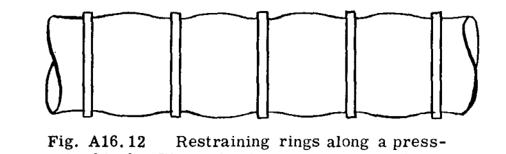

Fig. A16.12

リングとシェルの相互作用問題に対する1つの提案された解決策は、フローティングスキンである。基本的に、アイデアは、シェルが圧力荷重下で自由に膨張できるように、シェルとリングの間の接続の径方向剛性を低下させることである。リングと外板の間の接続は、リング荷重が接線方向の剪断流によってシェル壁に伝達できるように、依然としてその剪断剛性を維持しなければならない。図 A16-13 は、径方向に柔軟な接続の基本概念を示している。このタイプの「マウント」の多くのバリエーションが考えられ、そのうちのいくつかは他の理由で価値があるかもしれない。例えば、高速輸送機のキャビンへの風やその他の振動ノイズの伝達は、リングとシェルの間の接続を適切に選択することによって同時に処理できる問題である。

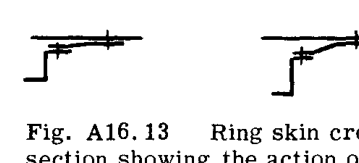

Fig. A16.13

- 補強リングの設計の特定の詳細は、コードや規格に記載されている。
- 尾翼からの曲げおよび剪断荷重によって主に荷重を受け、その上に圧力膜荷重が重畳される補強シェル問題の観点からこの問題を見ると、興味深い効果が現れる。内圧は圧縮側で湾曲した外板パネルを安定させる傾向があるため、ストリンガーとともに機能する外板の有効幅が増加する。断面の断面特性は、最大ファイバー応力の変化がほとんどまたはまったく生じないような方法で変化する可能性がある。実際、内圧荷重の追加によって最大引張応力が実際に減少することさえある！（参考文献 7 を参照）。

#### ドアと窓

過度の重量ペナルティを避けるためには、与圧キャビンのシェルにおけるさまざまな切り欠きを特別に考慮する必要がある。

図 A16-14a の加圧シリンダーから取り外されたパネルを考える。切り欠きを処理する一般的な慣行に従って、取り外されるパネルが切り欠きの周囲のメイン構造にどのような力を及ぼすかを決定し、次にこれらを取り消すために等しく反対の、自己平衡する一連の応力を重畳する。切り欠きの境界はその後無応力となり、メイン構造の新しい応力状態を乱すことなくパネルを取り外すことができる。

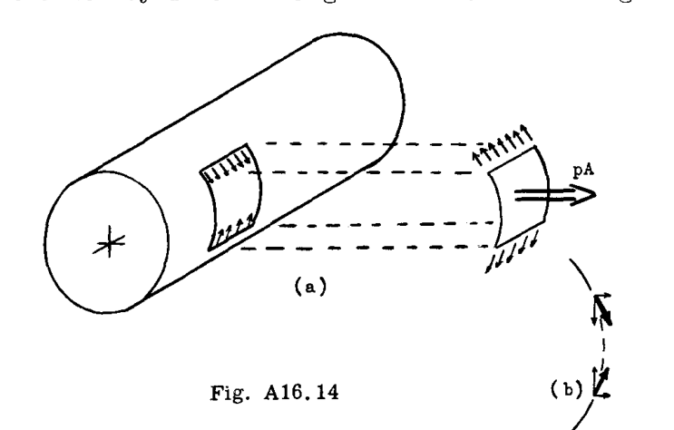

Fig. A16.14

切り欠きを囲む接線方向のフープ応力は、径方向の成分を有するため、自己平衡セットによって取り消すことができない。しかし、これらの応力の径方向成分は、実際には、フレームに対して外向きに押し付けられるドアまたは窓によって供給される。したがって、取り消す必要があるのは、弦に沿ったフープ応力の成分のみである（図 A16-14b）*。

当面の問題は、開口部の上端と下端を結ぶ弦の平面内で作用する、一様に分布した自己平衡応力のセットを効果的に支持する構造を設計することになる（図 A16-15a）。

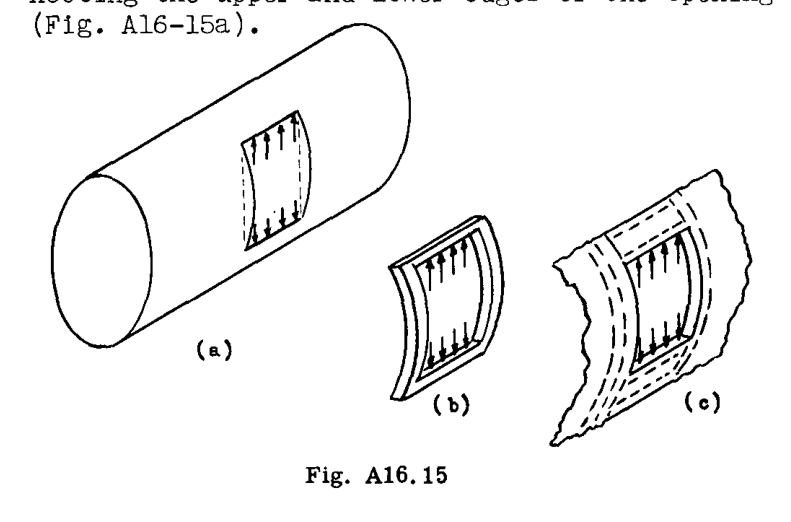

Fig. A16.15

応力システムを支持するために必要なのは、切り欠きの上部と下部に水平なヘッダーを提供することだけのようであり、これは梁として、荷重をフレームの側面に伝達し、そこで荷重が取り消される（図 A16-15b）。与圧胴体における通常のサイズの切り欠きの場合、この方法で支持される応力システムは非常に大きく、それらに抵抗するのに十分な曲げ剛性を持つ単一の水平フレーム部材を設計することは不経済であることが判明している。代わりに、これらの荷重を伝達するのを助けるためにシェル壁自体が採用される。外板はかなりの深さを持つ梁のウェブを形成するために使用され、外板はこの梁のウェブであり、水平フレーム部材と1つ以上の縦通材が梁のフランジを形成する（図 A16-15c）。

発生する重い剪断流と直接応力のため、外板は通常、この領域で二重にされる。応力を緩和するために追加のストリンガーを追加することもできる。切り欠きを囲む（そしてフレームの一部を形成する）リングは、切り欠き自体の上下にある程度の距離まで延長される（通常のリング位置と一致する場合を除く。その場合は全周にわたって配置される）。

図 A16-16 は、典型的な切り欠き構造の配置を示している。分析的なアプローチが試みられてきたが、このような構成における真の弾性応力分布を計算することはできないと言って差し支えない。高強度の応力集中（それに伴う疲労の可能性）を避ける必要性から、このようなケースでは実験データが最も有用である。一方、上記で概説した原理に基づく単純な合理的解析は、静的強度チェックおよびほとんどの設計目的において十分に役立つ可能性が高い。

上記の議論は、切り欠きの周りにフープ応力を伝達する問題に注意を集中させてきた。縦方向の圧力応力は、それ自体はより小さいものの、尾翼荷重からの曲げ応力によって強化される。したがって、切り欠きを横切る縦方向の応力は、この条件（または組み合わせ）を最も厳しいものにする可能性がある。

- 設計要件の1つは、ドアまたは窓がフレームに対して均一に支持できるように、径方向の力に対して曲げにおいてフレームを十分に剛にすることであることは明らかである。

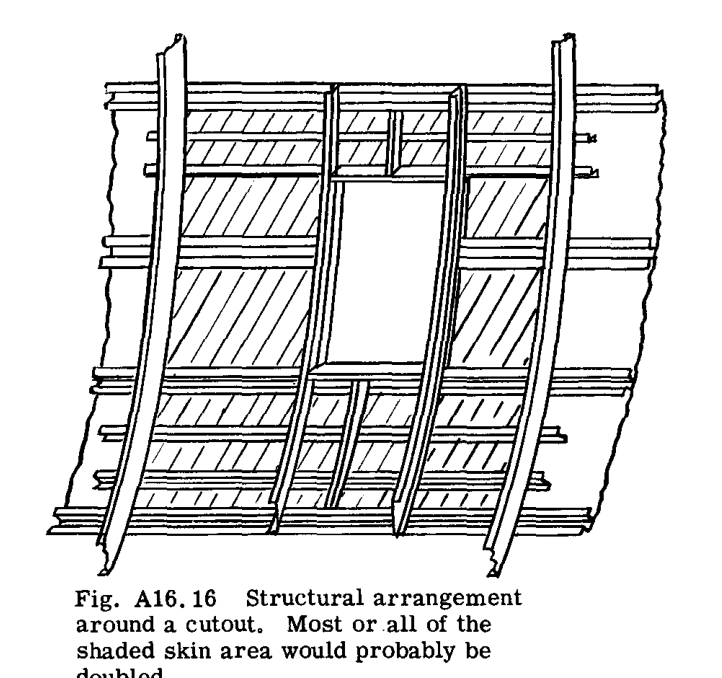

Fig. A16.16

#### 平面パネルの大きな変位；「キルティング」

与圧胴体において平らな外板パネルの使用を避けることは常にできるとは限らない。薄い外板は曲げ剛性がほとんどないため、梁（より正確には「板」）として横方向の圧力を支持することはできず、したがって、荷重を支持するいくつかの引張膜応力を発生させるためにたわまなければならない。境界を接する補強材の間の矩形の外板パネルの膨らみは、表面に「キルティング（羽毛布団のような）」外観を与える。

湾曲した外板パネルの場合でも、キルティングは発生する：内部の補強フレームワーク（横方向のリングとフレーム、および縦方向のストリンガー）が比較的剛性であり、外板にしっかりと固定されている場合、各外板パネルは、シェル膜応力に通常伴う径方向の膨張に対して4つの側面（境界）で拘束される。その結果は、図 A16-12* に示されている挙動の三次元的なケースのようなものになる。

構造的な観点から、キルティングの好ましくない側面は、パネルエッジの近くで発生する高い応力集中と、外板を補強材に結合するリベットに作用する引張荷重にある。キルティングされた表面の空力特性は、高性能航空機においては非常に望ましくない。したがって、ここでもキルティングは避けるべきである。

キルティングされたパネルにおける応力の計算は、大きな非線形たわみを伴うため困難である。追加の（そして非常に必要な）複雑さは、境界部材の剛性特性を導入しなければならないことである。読者は、この問題のさらなる議論について、第 A.17 章を参照されたい。そこでは、傾向を示す簡略化されたアプローチが、文献へのさらなる参考文献とともに示されている。

### A16.5 非対称荷重を受ける回転殻

回転殻が非対称な荷重を受ける問題は、航空機の構造解析において珍しいことではない。胴体の機首、外部燃料タンク、および突出したレドームは、外部の空力圧力によって非対称に荷重を受ける可能性のある回転殻である。やはり、同じ外部燃料タンクシェルは、シェル軸に垂直な方向の燃料の重量から非対称な内部静水圧荷重を受ける。

問題の非対称性のために、膜剪断応力が存在するようになり、したがって解析者は2つではなく、3つの未知数（ $N_m$ 、 $N_t$ 、および $N_s$ ）における3つの方程式を解かなければならない。さらに、これらは代数方程式ではなく微分方程式になる。

平衡の微分方程式の導出はかなり長く、それらの一般解は書き出すことができないため（むしろ、特定のケースに対する特定の解のみが見出される）、ここでは詳細は再現しない。方程式の導出および例題については、参考文献 2 の 373〜379 ページを参照されたい。

- 湾曲した外板におけるキルティングを減少させる1つの設計は、リングとフレームを「ハット」断面のストリンガーの内面にのみ固定することである。したがって、リングは外板に直接固定されず、外板は各リングの周囲で継続的に拘束されることはない。その結果、修正されたフローティングスキンが得られる。

### 参考文献

1. API-ASME* 統一圧力容器コード、1951年版、等。
2. Timoshenko, S. “Theory of Plates and Shells” McGraw-Hill, N.Y., 1940
3. Watts, G. and Lang, H., “Stresses in a Pressure Vessel With a Conical Head,” Trans. ASME, vol. 74, 1952, pp. 315-324.
4. ———–, “Stresses in a Pressure Vessel With a Flat Head Closure,” Trans. ASME, vol. 74, 1952, pp. 1083-1090.
5. ———–, “Stresses in a Pressure Vessel With a Hemispherical Head,” Trans. ASME, vol. 75, 1953, pp. 83-89.
6. Roark, R. J. “Formulas for Stress and Strain”, McGraw-Hill, N. Y. 3rd Edition, 1954.
7. Howland W. and Beed, C. “Tests of Pressurized Cabin Structures,” Jour. Aero. Sci. vol. Nov. 1940.

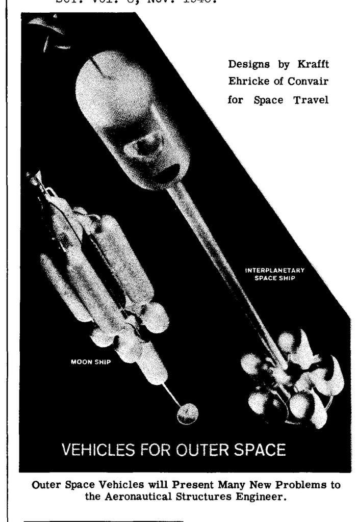

宇宙空間用車両

- 米国石油協会 - 米国機械工学会 (American Petroleum Institute - American Society of Mechanical Engineers)

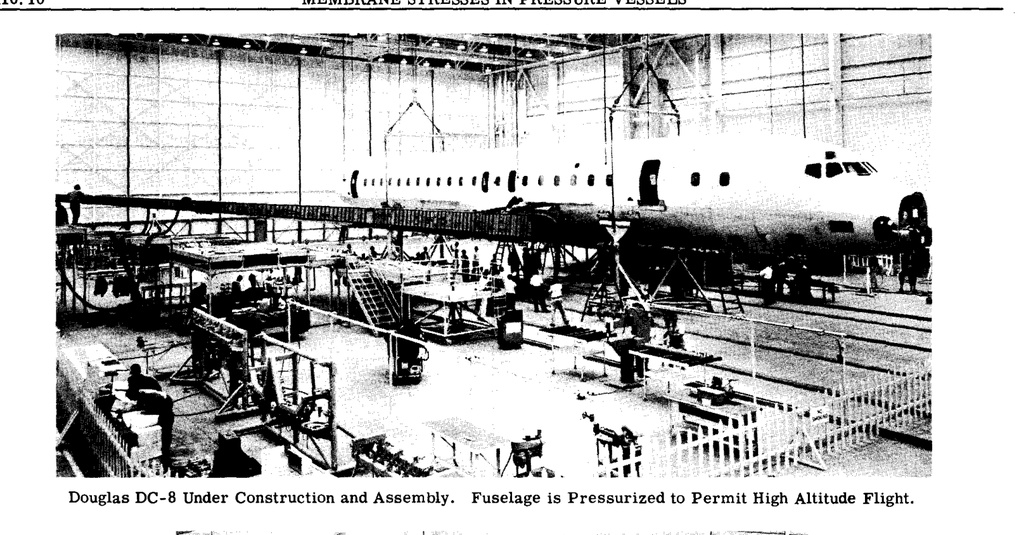

DC-8の製造と組立

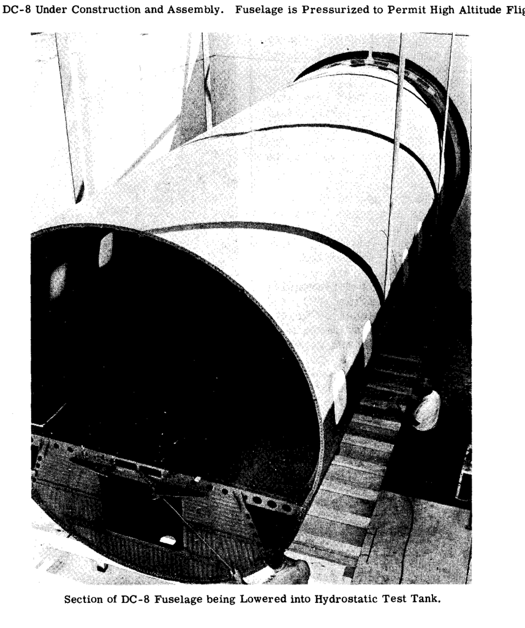

静水圧試験タンクに降ろされるDC-8胴体セクション